# ARIMA hw6

min cheng

11/21/2022

```r
library(readxl)
library(fpp)
library(fpp2)
library(forecast)

data <- read_excel("C:/Users/mchen/OneDrive/Desktop/2023fall syllasbus/Forecasting/homework/w3 2nd/Sample - Superstore.xls")
str(data)
```

```
## tibble [58 × 2] (S3: tbl_df/tbl/data.frame)
##  $ Date : POSIXct[1:58], format: "2014-01-01" "2014-02-01" ...
##  $ Sales: num [1:58] 26100 39600 73000 87200 87920 ...
```

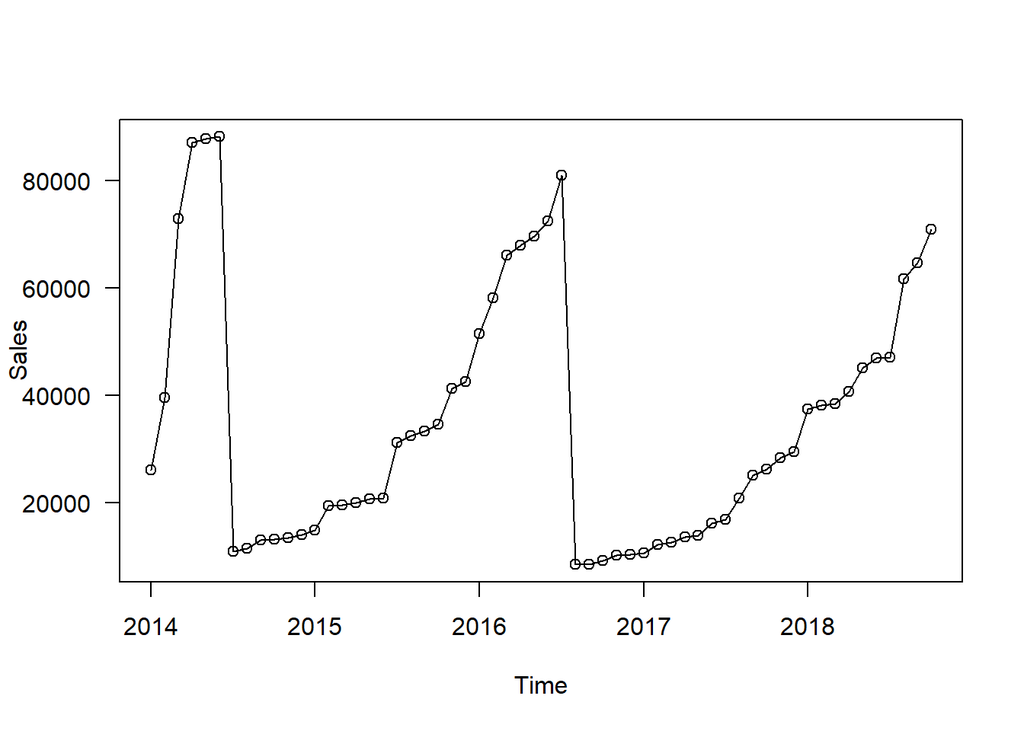

```r
datatimeseries <- ts(data$Sales, start=c(2014, 1), frequency=12)


plot(datatimeseries, xlab="Time", ylab="Sales", las=1, type="o")
```

**Insight:Significant dips in 2014-2015 and 2016-2017, with quick rebounds, could signal potential errors or outliers.**

```r
ndiffs(datatimeseries)
```

```
## [1] 0
```

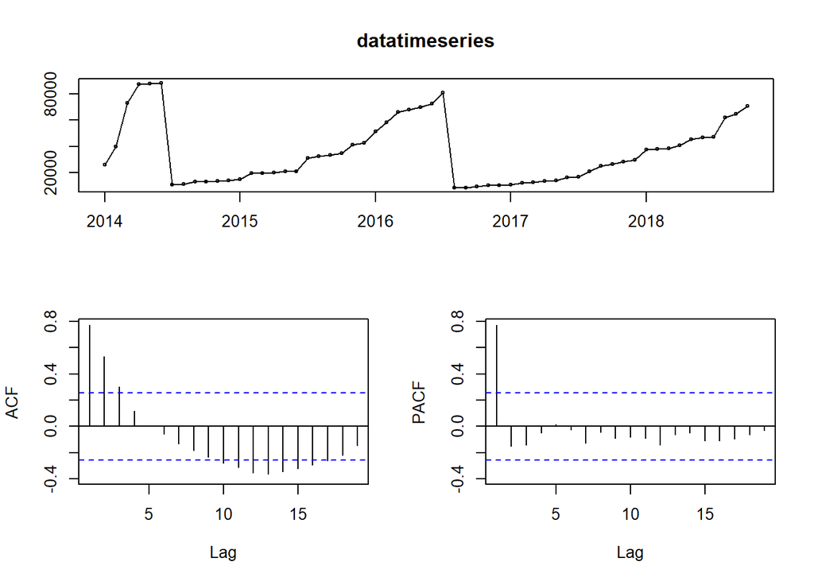

```r
tsdisplay(datatimeseries)
```

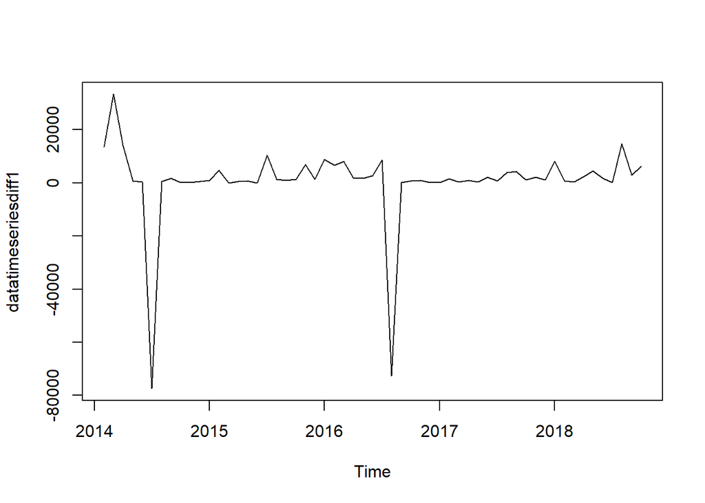

```r
datatimeseriesdiff1 <- diff(datatimeseries, differences=1)
plot(datatimeseriesdiff1)
```

#Differencing is a common technique in time series analysis used to transform a non-stationary time series into a stationary one. A stationary time series is characterized by statistical properties such as mean and variance that do not change over time. Often, non-stationary series can be made stationary through differencing, which makes them more suitable for modeling and forecasting.

#差分是时间序列分析中的一个常用技术，目的是将非平稳的时间序列转换为平稳序列。 #平稳序列的主要特征是其统计特性（如均值、方差）不随时间变化。在许多情况下，非平稳序列可以通过差分变换成平稳序列，从而更适合于建模和预测。一阶差分的计算方法是取当前时间点的观测值与前一个时间点的观测值之间的差The formula for the first order differencing is:

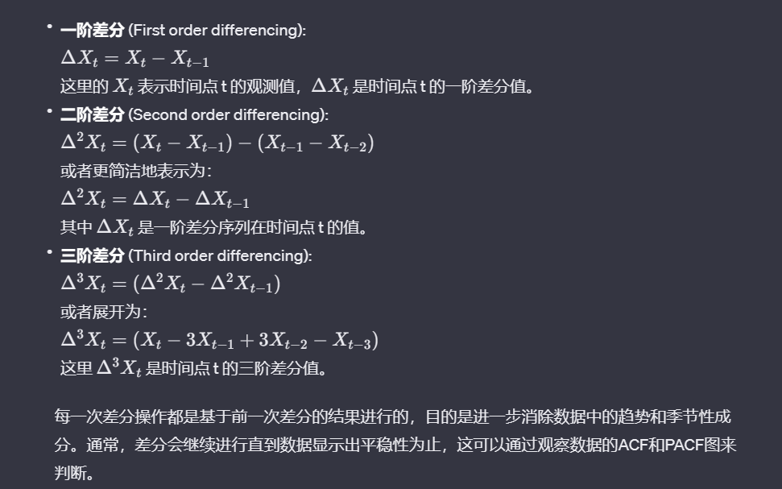

This is an image

#对于偏自相关函数（PACF），它会考虑到其他滞后值的影响，并尝试去除这些中间值的影响，来找到序列中一个值与另一个滞后值之间的纯粹关系。

[figure not shown]

This is an image

#3.Perform and Plot the forecast for the next five periods

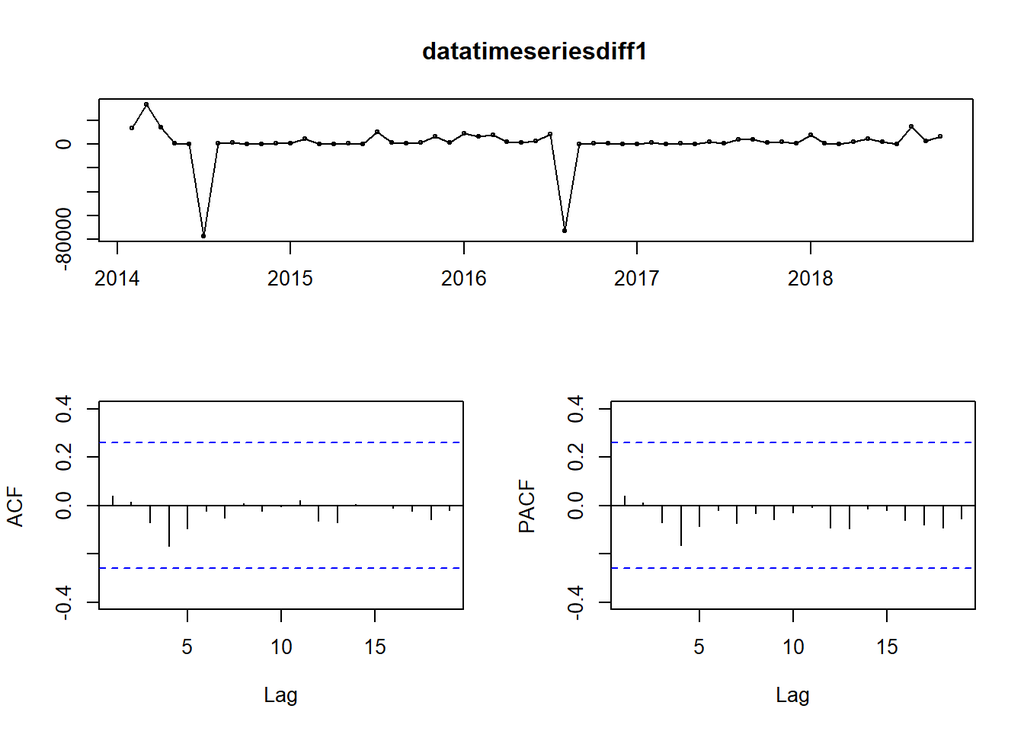

```r
tsdisplay(datatimeseriesdiff1)
```

```r
str(datatimeseries)
```

```
##  Time-Series [1:58] from 2014 to 2019: 26100 39600 73000 87200 87920 ...
```

```r
# Fit an ARIMA model to the 'Sales' time series
auto_fit <- auto.arima(datatimeseries, trace=TRUE, stepwise = FALSE)
```

```
##
##  ARIMA(0,0,0)            with zero mean     : 1402.529
##  ARIMA(0,0,0)            with non-zero mean : 1337.115
##  ARIMA(0,0,0)(0,0,1)[12] with zero mean     : 1399.292
##  ARIMA(0,0,0)(0,0,1)[12] with non-zero mean : 1332.62
##  ARIMA(0,0,0)(1,0,0)[12] with zero mean     : 1389.886
##  ARIMA(0,0,0)(1,0,0)[12] with non-zero mean : 1327.571
##  ARIMA(0,0,0)(1,0,1)[12] with zero mean     : Inf
##  ARIMA(0,0,0)(1,0,1)[12] with non-zero mean : 1327.476
##  ARIMA(0,0,1)            with zero mean     : 1352.632
##  ARIMA(0,0,1)            with non-zero mean : 1304.365
##  ARIMA(0,0,1)(0,0,1)[12] with zero mean     : 1350.321
##  ARIMA(0,0,1)(0,0,1)[12] with non-zero mean : 1301.777
##  ARIMA(0,0,1)(1,0,0)[12] with zero mean     : 1345.774
##  ARIMA(0,0,1)(1,0,0)[12] with non-zero mean : 1301.074
##  ARIMA(0,0,1)(1,0,1)[12] with zero mean     : Inf
##  ARIMA(0,0,1)(1,0,1)[12] with non-zero mean : 1303.406
##  ARIMA(0,0,2)            with zero mean     : 1329.192
##  ARIMA(0,0,2)            with non-zero mean : 1293.671
##  ARIMA(0,0,2)(0,0,1)[12] with zero mean     : 1328.845
##  ARIMA(0,0,2)(0,0,1)[12] with non-zero mean : 1292.365
##  ARIMA(0,0,2)(1,0,0)[12] with zero mean     : 1327.039
##  ARIMA(0,0,2)(1,0,0)[12] with non-zero mean : 1292.577
##  ARIMA(0,0,2)(1,0,1)[12] with zero mean     : Inf
##  ARIMA(0,0,2)(1,0,1)[12] with non-zero mean : 1294.85
##  ARIMA(0,0,3)            with zero mean     : 1314.115
##  ARIMA(0,0,3)            with non-zero mean : 1288.697
##  ARIMA(0,0,3)(0,0,1)[12] with zero mean     : 1314.899
##  ARIMA(0,0,3)(0,0,1)[12] with non-zero mean : 1288.866
##  ARIMA(0,0,3)(1,0,0)[12] with zero mean     : 1314.418
##  ARIMA(0,0,3)(1,0,0)[12] with non-zero mean : 1289.308
##  ARIMA(0,0,3)(1,0,1)[12] with zero mean     : Inf
##  ARIMA(0,0,3)(1,0,1)[12] with non-zero mean : 1291.122
##  ARIMA(0,0,4)            with zero mean     : 1308.232
##  ARIMA(0,0,4)            with non-zero mean : 1288.911
##  ARIMA(0,0,4)(0,0,1)[12] with zero mean     : 1309.234
##  ARIMA(0,0,4)(0,0,1)[12] with non-zero mean : 1289.553
##  ARIMA(0,0,4)(1,0,0)[12] with zero mean     : 1309.225
##  ARIMA(0,0,4)(1,0,0)[12] with non-zero mean : 1290.157
##  ARIMA(0,0,5)            with zero mean     : 1306.11
```

[output cut: 72 more lines]

```
##  ARIMA(3,0,2)            with non-zero mean : Inf
##  ARIMA(4,0,0)            with zero mean     : 1294.785
##  ARIMA(4,0,0)            with non-zero mean : 1288.189
##  ARIMA(4,0,0)(0,0,1)[12] with zero mean     : 1297.032
##  ARIMA(4,0,0)(0,0,1)[12] with non-zero mean : 1288.279
##  ARIMA(4,0,0)(1,0,0)[12] with zero mean     : 1297.116
##  ARIMA(4,0,0)(1,0,0)[12] with non-zero mean : 1289.218
##  ARIMA(4,0,1)            with zero mean     : Inf
##  ARIMA(4,0,1)            with non-zero mean : 1290.751
##  ARIMA(5,0,0)            with zero mean     : 1296.189
##  ARIMA(5,0,0)            with non-zero mean : 1290.764
##
##
##
##  Best model: ARIMA(1,0,0)            with non-zero mean
```

```r
auto_fit
```

```
## Series: datatimeseries
## ARIMA(1,0,0) with non-zero mean
##
## Coefficients:
##          ar1       mean
##       0.7885  36668.907
## s.e.  0.0799   8579.978
##
## sigma^2 = 2.22e+08:  log likelihood = -639.09
## AIC=1284.18   AICc=1284.62   BIC=1290.36
```

```r
attributes(auto_fit)
```

```
## $names
##  [1] "coef"      "sigma2"    "var.coef"  "mask"      "loglik"    "aic"
##  [7] "arma"      "residuals" "call"      "series"    "code"      "n.cond"
## [13] "nobs"      "model"     "bic"       "aicc"      "x"         "fitted"
##
## $class
## [1] "forecast_ARIMA" "ARIMA"          "Arima"
```

```r
forecast<-(forecast(auto_fit,h=5,level=c(99.5)))

forecast
```

```
##          Point Forecast    Lo 99.5  Hi 99.5
## Nov 2018       63674.02  21853.527 105494.5
## Dec 2018       57962.21   4705.179 111219.2
## Jan 2019       53458.49  -5806.520 112723.5
## Feb 2019       49907.35 -12803.434 112618.1
## Mar 2019       47107.31 -17653.418 111868.0
```

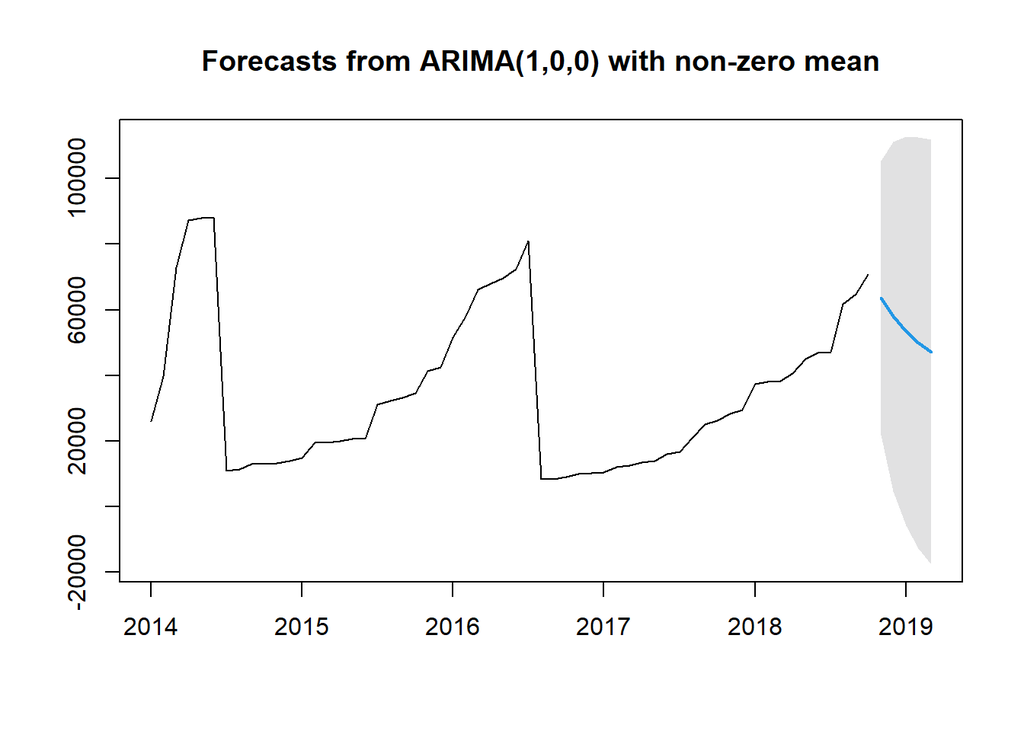

```r
plot(forecast)
```

**Insight:the resulting plot looks more like a fluctuation around a constant mean without a trend, then the differencing process has helped in stabilizing the mean of the series by removing the trend,the differencing was successful.ACF and PACF show that most of the autocorrelations at various lags are not significant(each bar black, has not exceed the blue dotted line significance boundary, indicates ), suggesting that the time series may not exhibit strong autocorrelation.**

**Question: the datatimeseriesdiff1 shows that differencing stablize the series,compared with line graph datatime series line graph, but the acf &pacf in this step indicates not strong autocorrelation , it means the differnecing was successful or not?

#2.Residual Analysis

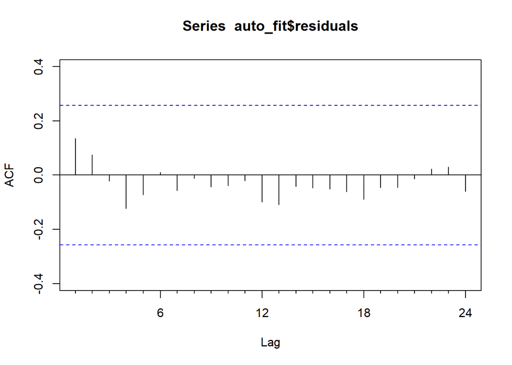

```r
Acf(auto_fit$residuals)
```

```r
Box.test(residuals(auto_fit), lag=20, type="Ljung")
```

```
##
##  Box-Ljung test
##
## data:  residuals(auto_fit)
## X-squared = 6.9434, df = 20, p-value = 0.9969
```

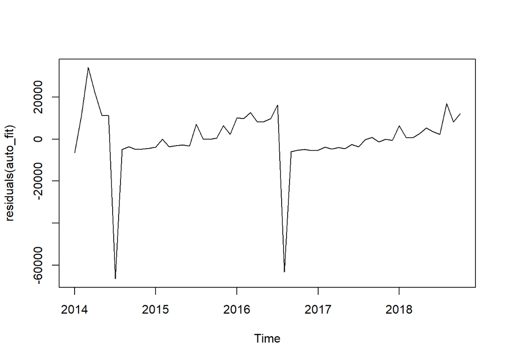

```r
plot.ts(residuals(auto_fit))
```

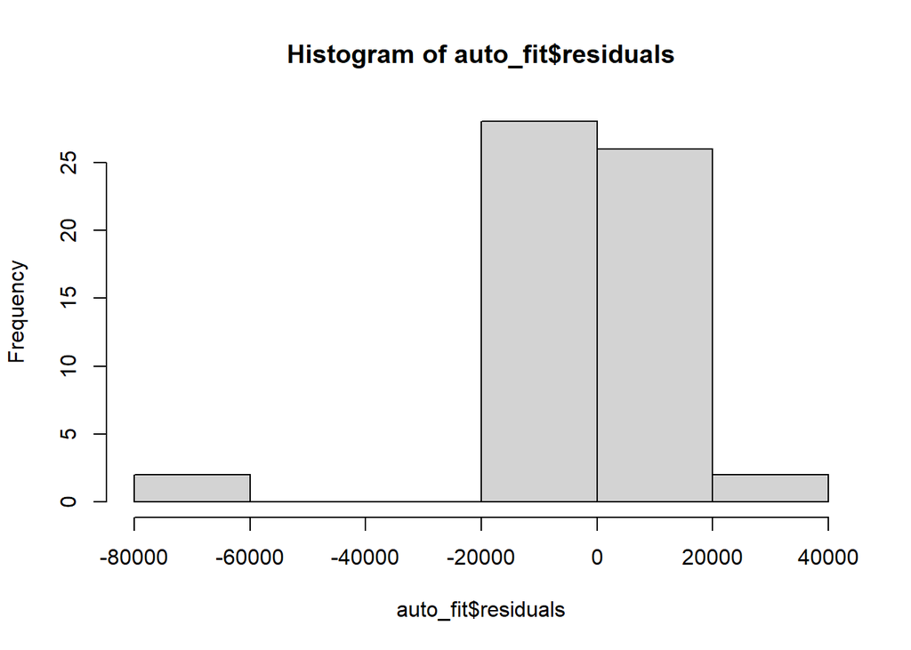

```r
hist(auto_fit$residuals)
```

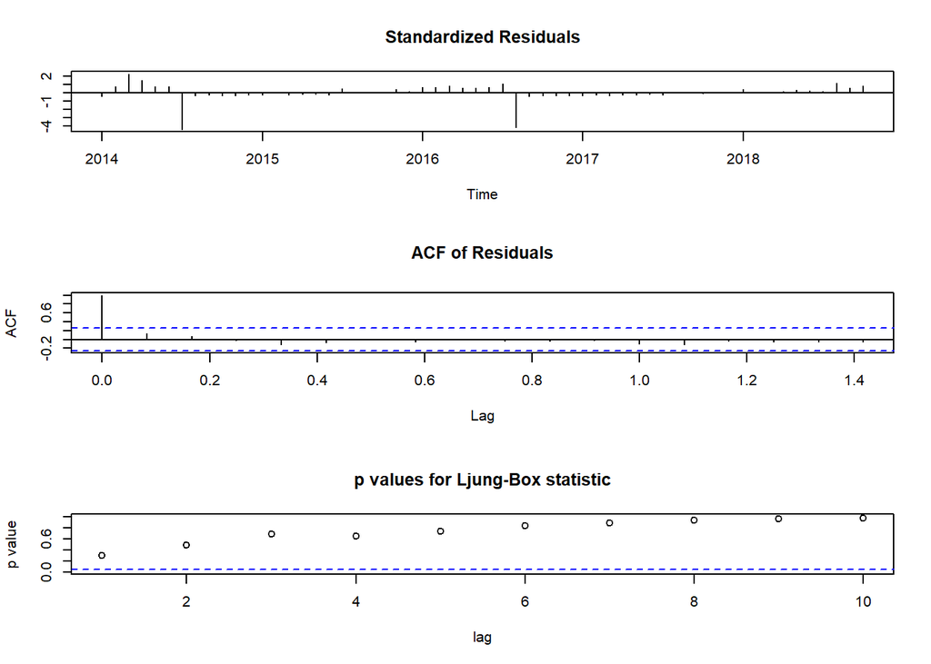

```r
tsdiag(auto_fit)
```

4.Show the accuracy of your ARIMA model

```r
accuracy(auto_fit)
```

```
##                    ME     RMSE      MAE       MPE     MAPE      MASE      ACF1
## Training set 211.7257 14639.34 8085.073 -29.65904 43.30889 0.2236592 0.1345437
```

**MAPE of 43.31% suggests that, on average, the model’s forecasts have a 43.31% absolute percentage error.**